# The Impact of Temperature and Precipitation on Annual Crop Yield in North America

This script shows the data analysis for the research paper: "The Impact of Temperature and Precipitation on Annual Crop Yield in North America".

Paper and analysis by:

Maxim Mahnkopf, Dominic Schierbaum and Nick van Nuland

# Part 1 (Python)

Import Packages

```python
import xarray as xr
import os
```

Set Path

```python
# os.chdir(r"your/path")
```

## Climate Variables: Access and Calculating Seasonal Mean

Access the Data Cube

```python
zarr_path = "http://data.rsc4earth.de/EarthSystemDataCube/v2.1.0/esdc-8d-0.083deg-1x2160x4320-2.1.0.zarr"
data_cube = xr.open_zarr(zarr_path)
```

Choose Climate Variables, Region and Time Period

```python
climate_variable = ["air_temperature_2m","precipitation"]
subset = data_cube[climate_variable].sel(lon=slice(-169.05, -53.0), lat=slice(71.0, 25.0),time=slice('1982', '2016'))
```

Calcualte the Seasonal Mean Over the Growing Period for the Climate Variables

```python
subset = subset.sel(time=subset['time.month'].isin([4, 5, 6, 7, 8, 9]))
seasonal_mean = subset['air_temperature_2m'].groupby('time.year').mean(dim='time')
seasonal_precipitation = subset['precipitation'].groupby('time.year').sum(dim='time')

seasonal = xr.Dataset({
  'temperature': (['year', 'lat', 'lon'], seasonal_mean.data),
  'precipitation': (['year', 'lat', 'lon'], seasonal_precipitation.data)
}, coords={
  'year': seasonal_mean['year'],
  'lat': seasonal_mean['lat'],
  'lon': seasonal_mean['lon']
})
```

```python
# export seasonal mean data
seasonal.to_netcdf("data/seasonal.nc4")

# this execution can take up to 15 minutes
```

## Crop Yield Data (GDHY): Stacking

Stack All nc4 Files: Make sure you have downloaded the crop yield data from the git repo: https://github.com/mxkopf/Crop_Yield_Climate_Var

The data set in the github repo was downloaded from the original paper: https://doi.pangaea.de/10.1594/PANGAEA.909132

Spring Wheat

```python
directory = 'data/wheat'
sorted_files = sorted(os.listdir(directory), key=lambda x: int(x.split('_')[1].split('.')[0]))
wheat = xr.Dataset()

for filename in sorted_files:
    if filename.endswith(".nc4"):
        filepath = os.path.join(directory, filename)
        ds = xr.open_dataset(filepath, engine='netcdf4')
        wheat = xr.concat([wheat, ds], dim='time')

# Define 'time' as a coordinate variable
wheat = wheat.assign_coords(time=wheat.time)

# Export the stacked dataset to a new NetCDF4 file
output_file = "data/wheat_stacked.nc4"
wheat.to_netcdf(output_file, format='netCDF4')

print(f"Stacked dataset saved to {output_file}")
```

```
Stacked dataset saved to data/wheat_stacked.nc4
```

Maize

```python
directory = 'data/maize'
sorted_files = sorted(os.listdir(directory), key=lambda x: int(x.split('_')[1].split('.')[0]))
maize = xr.Dataset()

for filename in sorted_files:
    if filename.endswith(".nc4"):
        filepath = os.path.join(directory, filename)
        ds = xr.open_dataset(filepath, engine='netcdf4')
        maize = xr.concat([maize, ds], dim='time')

# Define 'time' as a coordinate variable
maize = maize.assign_coords(time=maize.time)

# Export the stacked dataset to a new NetCDF4 file
output_file = "data/maize_stacked.nc4"
maize.to_netcdf(output_file, format='netCDF4')

print(f"Stacked dataset saved to {output_file}")
```

```
Stacked dataset saved to data/maize_stacked.nc4
```

Soybean

```python
directory = 'data/soybean'
sorted_files = sorted(os.listdir(directory), key=lambda x: int(x.split('_')[1].split('.')[0]))
soybean = xr.Dataset()

for filename in sorted_files:
    if filename.endswith(".nc4"):
        filepath = os.path.join(directory, filename)
        ds = xr.open_dataset(filepath, engine='netcdf4')
        soybean = xr.concat([soybean, ds], dim='time')

# Define 'time' as a coordinate variable
soybean = soybean.assign_coords(time=soybean.time)

# Export the stacked dataset to a new NetCDF4 file
output_file = "data/soybean_stacked.nc4"
soybean.to_netcdf(output_file, format='netCDF4')

print(f"Stacked dataset saved to {output_file}")
```

```
Stacked dataset saved to data/soybean_stacked.nc4
```

## Part 2 (R)

# Crop Yield Data (GDHY): Rotating and Croping

Load R Library

```r
library(ncdf4)
library(rasterVis)
library(raster)
library(ggplot2)
library(rgdal)
library(sf)
```

Set Path

```r
# setwd("your/path")
```

Rotate The Crop Yield Data Set

Load Crop Yield Data

```r
maize <- raster::stack("data/maize_stacked.nc4")
soybean <- raster::stack("data/soybean_stacked.nc4")
spring_wheat <- raster::stack("data/wheat_stacked.nc4")
```

Rotate Data

```r
# rotate longitude: from (0° : 360°) to (-180° : 180°)
maize <- rotate(maize, left = FALSE, overwrite=TRUE)
soybean <- rotate(soybean, left = FALSE, overwrite=TRUE)
spring_wheat <- rotate(spring_wheat, left = FALSE, overwrite=TRUE)
```

Crop Data Set to Extent

```r
# Define the extent
min_lon <- -169.0
max_lon <- -53.0
min_lat <- 25.0
max_lat <- 71.0
na_extent <- extent( min_lon, max_lon, min_lat, max_lat)
maize<- crop(maize, na_extent)
soybean<- crop(soybean, na_extent)
spring_wheat<- crop(spring_wheat, na_extent)
```

Delete Year 1981 Since the Data for this Year is Insufficient

```r
maize           <- subset(maize, 2:36)
soybean         <- subset(soybean, 2:36)
spring_wheat    <- subset(spring_wheat, 2:36)
```

Export

```r
writeRaster(spring_wheat, filename = "data/wheat_stacked_rotated.nc",format = "CDF",overwrite=T)
writeRaster(soybean, filename = "data/soybean_stacked_rotated.nc",format = "CDF",overwrite=T)
writeRaster(maize, filename = "data/maize_stacked_rotated.nc",format = "CDF",overwrite=T)
```

# Part 3 (Python)

# Resampling and Stacking to Data Cube

Import packages

```python
import xarray as xr
import dask.array as da
import numpy as np
import os
```

Set Path

```python
#os.chdir(r"your/path")
```

Open Crop Yield Data

```python
spring_wheat = xr.open_dataset("data/wheat_stacked_rotated.nc", engine='netcdf4')
soybean = xr.open_dataset("data/soybean_stacked_rotated.nc", engine='netcdf4')
maize = xr.open_dataset("data/maize_stacked_rotated.nc", engine='netcdf4')
```

Rename Year

```python
spring_wheat['z'] = list(range(1982,2017))
soybean['z'] = list(range(1982,2017))
maize['z'] = list(range(1982,2017))
spring_wheat = spring_wheat.sel(z=slice('1982', '2016'))
soybean = soybean.sel(z=slice('1982', '2016'))
maize = maize.sel(z=slice('1982', '2016'))
spring_wheat = spring_wheat.rename({'z': 'year'})
soybean = soybean.rename({'z': 'year'})
maize = maize.rename({'z': 'year'})
```

Open Climate Variables

```python
seasonal = xr.open_dataset("data/seasonal.nc4", engine='netcdf4')
```

Resample (to Resolution of Crop Yield Data)

```python
gdhy_lat = maize.latitude
gdhy_lon = maize.longitude
```

```python
resampled_data = seasonal.interp(lat=gdhy_lat, lon=gdhy_lon, method='linear')
```

Expot as Datacube

```python
maize_da = da.from_array(maize['variable'],chunks=(35,92,232))
soybean_da = da.from_array(soybean['variable'],chunks=(35,92,232))
wheat_da = da.from_array(spring_wheat['variable'],chunks=(35,92,232))
```

```python
dims = ('year', 'latitude', 'longitude')
resampled_data['maize'] =(dims ,  maize_da)
resampled_data['soybean'] =(dims ,  soybean_da)
resampled_data['wheat'] =(dims ,  wheat_da)
```

```python
resampled_data.to_netcdf('data/datacube_final.nc')
```

# Part 4 (R)

# Statistical Analysis

This code provides the statistical analysis of the research paper: The Impact of Temperature and Precipitation on Annual Crop Yield in North America.

Paper and analysis by:

Maxim Mahnkopf, Dominic Schierbaum and Nick van Nuland

Load R Library

```r
library(ncdf4)
library(rasterVis)
library(raster)
library(ggplot2)
library(rgdal)
library(sf)
library(pracma)
library(dplyr)
library(terra)
library(Metrics)
```

Set Path

```r
# setwd("your/path")
```

# Data Preprocessing

Load Data

```r
datacube <- nc_open("data/datacube_final.nc")
```

```r
names(datacube[['var']])
```

1. 'temperature'

2. 'precipitation'

3. 'lat'

4. 'lon'

5. 'maize'

6. 'soybean'

7. 'wheat'

```r
# load variables
maize                     <-   raster::stack(raster::stack(datacube[1],varname="maize"))
soybean                   <-   raster::stack(raster::stack(datacube[1],varname="soybean"))
spring_wheat              <-   raster::stack(raster::stack(datacube[1],varname="wheat"))
precipitation             <-   raster::stack(raster::stack(datacube[1],varname="precipitation"))
temperature               <-   raster::stack(raster::stack(datacube[1],varname="temperature"))
```

Change Year Names

```r
# creating a year vector
year_vector <- as.character(1982:2016)

# exchange
names(temperature@layers)[1:35] <- year_vector
names(precipitation@layers)[1:35] <- year_vector
names(maize@layers)[1:35] <- year_vector
names(soybean@layers)[1:35] <- year_vector
names(spring_wheat@layers)[1:35] <- year_vector
```

```r
datacube <- stack(maize, soybean, spring_wheat, precipitation, temperature)
```

Check for NAs in Datacube

```r
nlayers(datacube)
```

175

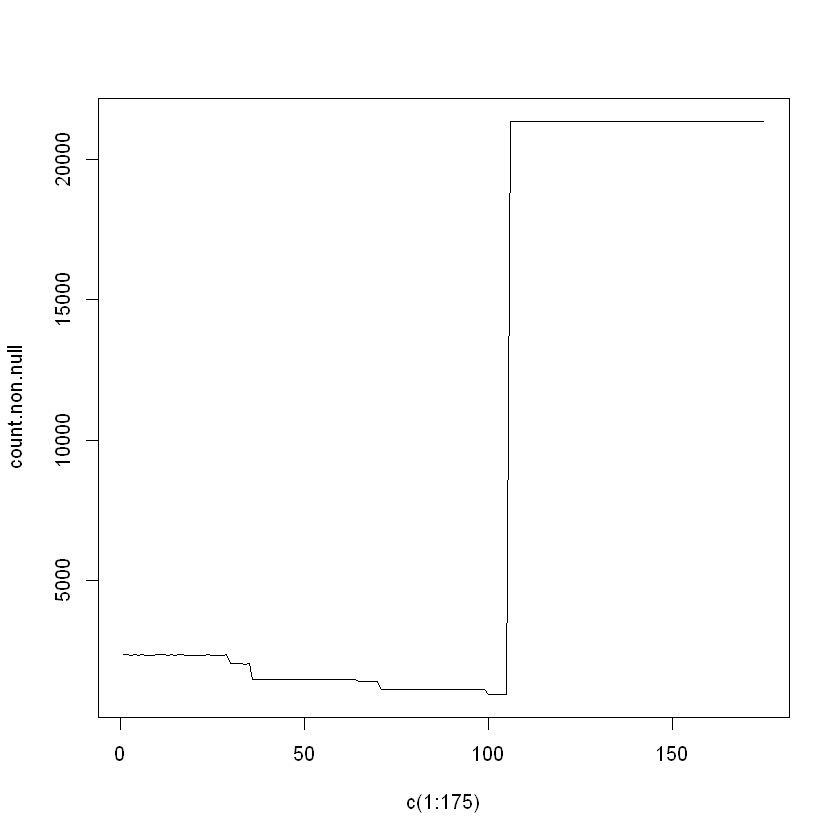

```r
count.non.null <- list()
for (i in 1:175){
  count.non.null[[i]] <- sum(!is.na(values(datacube[[i]])))
}
plot(c(1:175), count.non.null, type="l")
```

```r
# while precipitation (106:140) and temperature (141:175) have no NA values, maize, soybean and spring_wheat have about 80% to 90% NA values.
# this does make a lot of sense, since not more that 20% is agricultural area for each crop type
# also: the line for maize (1:35), soybean (36:70) and spring_wheat (71:105) is not straight --> this indicates that the years have inconsistent amounts of NA values
```

Clean Out All Rows with Inconcistent NAs

```r
# for maize
maize.mask <- datacube[[35]]    # get the last year as mask
for (i in 1:35) {
  # Extract the data for the current year
  layer <- mask(datacube[[i]], maize.mask)
  # Add the cleaned data to the raster stack
   datacube[[i]] <- layer
}

# for soybean
soybean.mask <- datacube[[70]]
for (i in 36:70) {
  # Extract the data for the current year
  layer <- mask(datacube[[i]], soybean.mask)
  # Add the cleaned data to the raster stack
  datacube[[i]] <- layer
}

# for spring_wheat
wheat.mask <- datacube[[105]]
for (i in 71:105) {
  # Extract the data for the current year
  layer <- mask(datacube[[i]], wheat.mask)
  # Add the cleaned data to the raster stack
  datacube[[i]] <- layer
}
```

Detrend Crop Yield Data

```r
# detrending with this detrend function from the pracma package:
fun_detr <- function(x) {detrend(x, tt='linear', bp=c())}
```

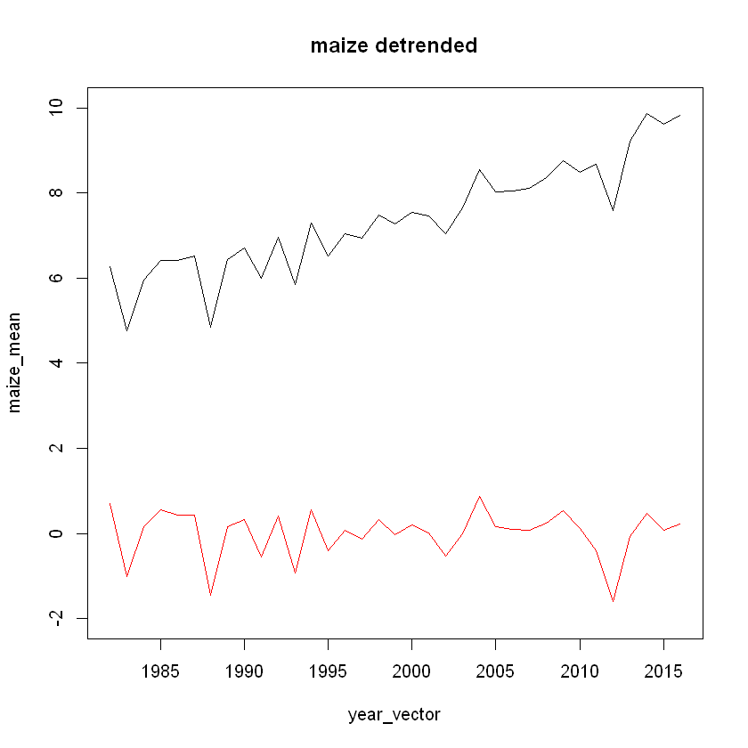

```r
#maize
x1 <- calc(datacube[[1:35]], fun_detr)
maize_detrend <- stack()
for (i in 1:nlayers(x1)) {
  layer <- x1[[i]]
  datacube[[i]] <- layer
}
#plot detre nding
maize_detrend_mean <- cellStats(datacube[[1:35]], mean)
maize_mean <- cellStats(maize, mean)
plot(year_vector, maize_mean , type="l", main="maize detrended",ylim = c(-2, 10))
lines(year_vector,maize_detrend_mean , type="l", col="red")
```

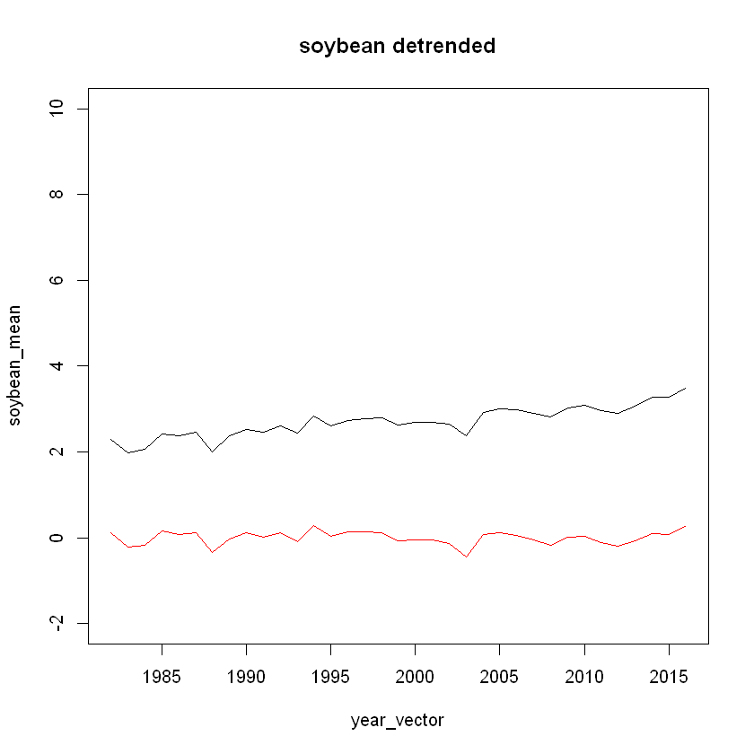

```r
#soybean
x2 <- calc(datacube[[36:70]], fun_detr)
soybean_detrend <- stack()
for (i in 1:nlayers(x2)) {
  layer <- x2[[i]]
  datacube[[i+35]] <- layer
}

#plot detrending
soybean_detrend_mean <- cellStats(datacube[[36:70]], mean)
soybean_mean <- cellStats(soybean, mean)
plot(year_vector, soybean_mean , type="l", main="soybean detrended",ylim = c(-2, 10))
lines(year_vector,soybean_detrend_mean , type="l", col="red")
```

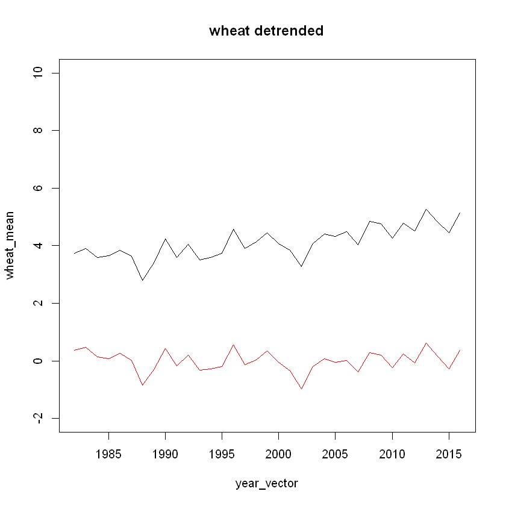

```r
#wheat
x3 <- calc(datacube[[71:105]], fun_detr)
wheat_detrend <- stack()
for (i in 1:nlayers(x3)) {
  layer <- x3[[i]]
  datacube[[i+70]] <- layer
}
#plot detrending
wheat_detrend_mean <- cellStats(datacube[[71:105]], mean)
wheat_mean <- cellStats(spring_wheat, mean)
plot(year_vector, wheat_mean , type="l", main="wheat detrended",ylim = c(-2, 10))
lines(year_vector,wheat_detrend_mean , type="l", col="red")
```

# Prediction Model (Linear Rregression): Temperature

Create Temperature Data Frame

```r
# Create an empty data frame to store the values
x_df_temp <- data.frame()
# Loop through the indices from 1 to 35
for (i in 1:35) {
  # Extract values from the raster object at index i
  x_values <- raster::values(temperature[[i]])

  # Create a new row in the data frame and assign the values to it
  x_df_temp <- rbind(x_df_temp, x_values)
}

# change col names
colnames(x_df_temp) <- c(1:21344)
# change from K to C
x_df_temp <- x_df_temp - 273
```

Create Crop Yield Data Frame

```r
#--------------------------------------------------------------------###maize###
# Create an empty data frame to store the values
y_df_maize <- data.frame()
# Loop through the indices from 1 to 35
for (i in 1:35) {
  # Extract values from the raster object
  y_values <- raster::values(datacube[[i]])

  # Create a new row in the data frame and assign the values to it
  y_df_maize <- rbind(y_df_maize, y_values)
}
# change col names
colnames(y_df_maize) <- c(1:21344)

#------------------------------------------------------------------###soybean###
# Create an empty data frame to store the values
y_df_soybean <- data.frame()
# Loop through the indices from 1 to 35
for (i in 1:35) {
  # Extract values from the raster object
  y_values <- raster::values(datacube[[i+35]])

  # Create a new row in the data frame and assign the values to it
  y_df_soybean <- rbind(y_df_soybean, y_values)
}
# change col names
colnames(y_df_soybean) <- c(1:21344)

#--------------------------------------------------------------------###spring_wheat###
# Create an empty data frame to store the values
y_df_wheat <- data.frame()
# Loop through the indices from 1 to 35
for (i in 1:35) {
  # Extract values from the raster object
  y_values <- raster::values(datacube[[i+70]])

  # Create a new row in the data frame and assign the values to it
  y_df_wheat <- rbind(y_df_wheat, y_values)
}
# change col names
colnames(y_df_wheat) <- c(1:21344)
```

Round Data - (Binning: For Noise Reduction)

```r
#rotate data
x_temp <- t(x_df_temp)
y_maize <- t(y_df_maize)
y_soybean <- t(y_df_soybean)
y_wheat <- t(y_df_wheat)

#round data
x_temp <- round(x_temp, digits = 0)
data_temp_maize <- data.frame(x = x_temp, y = y_maize)
data_temp_soybean <- data.frame(x = x_temp, y = y_soybean)
data_temp_wheat <- data.frame(x = x_temp, y = y_wheat)

#--------------------------------------------------------------------------maize
#Combine all rows from columns x.1 to x.35 into a single x column
data_all_x_maize <- data_temp_maize  %>%
  select(starts_with("x.")) %>%
  unlist() %>%
  as.data.frame() %>%
  setNames("x")

#Combine all rows from columns y.1 to y.35 into a single y column
data_all_y_maize <- data_temp_maize %>%
  select(starts_with("y.")) %>%
  unlist() %>%
  as.data.frame() %>%
  setNames("y")

#Combine x and y dataframes into data_all
temp_maize <- cbind(data_all_x_maize, data_all_y_maize)

#calculate mean data frame
mean_temp_maize <- temp_maize %>%
  group_by(x) %>%
  summarise(y = mean(y,na.rm=T))
#------------------------------------------------------------------------soybean
#Combine all rows from columns x.1 to x.35 into a single x column
data_all_x_soybean <- data_temp_soybean  %>%
  select(starts_with("x.")) %>%
  unlist() %>%
  as.data.frame() %>%
  setNames("x")

#Combine all rows from columns y.1 to y.35 into a single y column
data_all_y_soybean <- data_temp_soybean %>%
  select(starts_with("y.")) %>%
  unlist() %>%
  as.data.frame() %>%
  setNames("y")

#Combine x and y dataframes into data_all
temp_soybean <- cbind(data_all_x_soybean, data_all_y_soybean)

#calculate mean data frame
mean_temp_soybean <- temp_soybean %>%
  group_by(x) %>%
  summarise(y = mean(y,na.rm=T))
#--------------------------------------------------------------------------wheat
#Combine all rows from columns x.1 to x.35 into a single x column
data_all_x_wheat <- data_temp_wheat  %>%
  select(starts_with("x.")) %>%
  unlist() %>%
  as.data.frame() %>%
  setNames("x")

#Combine all rows from columns y.1 to y.35 into a single y column
data_all_y_wheat <- data_temp_wheat %>%
  select(starts_with("y.")) %>%
  unlist() %>%
  as.data.frame() %>%
  setNames("y")

#Combine x and y dataframes into data_all
temp_wheat <- cbind(data_all_x_wheat, data_all_y_wheat)

#calculate mean data frame
mean_temp_wheat <- temp_wheat %>%
  group_by(x) %>%
  summarise(y = mean(y,na.rm=T))
```

Plot It

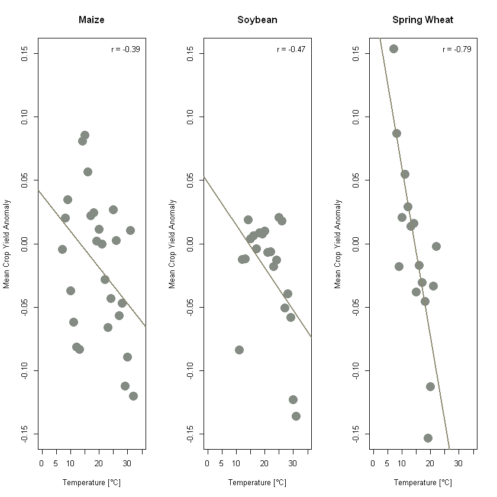

```r
# Set up a 1x3 multi-panel layout
par(mfrow = c(1, 3))

# Plot for maize
plot(mean_temp_maize$x, mean_temp_maize$y, pch = 16, cex = 2.5, bg = "honeydew3", col = "honeydew4",
     xlab = "Temperature [°C]", ylab = "Mean Crop Yield Anomaly", main = "Maize", xlim = c(0, 35),ylim= c(-0.15, 0.15))
correlation <- cor(mean_temp_maize$x, mean_temp_maize$y, use = "complete.obs")
legend("topright", paste("r =", round(correlation, 2)), bty = "n")
regression_model <- lm(y ~ x, data = mean_temp_maize)
abline(regression_model, col = "lemonchiffon4",lwd=2)

# Plot for soybean
plot(mean_temp_soybean$x, mean_temp_soybean$y, pch = 16, cex = 2.5, bg = "honeydew3", col = "honeydew4",
     xlab = "Temperature [°C]", ylab = "Mean Crop Yield Anomaly", main = "Soybean", xlim = c(0, 35),ylim= c(-0.15, 0.15))
correlation <- cor(mean_temp_soybean$x, mean_temp_soybean$y, use = "complete.obs")
legend("topright", paste("r =", round(correlation, 2)), bty = "n")
regression_model <- lm(y ~ x, data = mean_temp_soybean)
abline(regression_model, col = "lemonchiffon4",lwd=2)

# Plot for wheat
plot(mean_temp_wheat$x, mean_temp_wheat$y, pch = 16, cex = 2.5, bg = "honeydew3", col = "honeydew4",
     xlab = "Temperature [°C]", ylab = "Mean Crop Yield Anomaly", main = "Spring Wheat", xlim = c(0, 35),ylim= c(-0.15, 0.15))
correlation <- cor(mean_temp_wheat$x, mean_temp_wheat$y, use = "complete.obs")
legend("topright", paste("r =", round(correlation, 2)), bty = "n")
regression_model <- lm(y ~ x, data = mean_temp_wheat)
abline(regression_model, col = "lemonchiffon4",lwd=2)

# Reset the layout to a single panel
par(mfrow = c(1, 1))
```

# Prediction Model (Linear Rregression): Precipitation

Create Precipitation Data Frame

```r
# Create an empty data frame to store the values
x_df_prec <- data.frame()
# Loop through the indices from 1 to 35
for (i in 1:35) {
  # Extract values from the raster object at index i
  x_values <- raster::values(datacube[[i+105]])

  # Create a new row in the data frame and assign the values to it
  x_df_prec <- rbind(x_df_prec, x_values)
}
# change col names
colnames(x_df_prec) <- c(1:21344)
```

Create Crop Yield Data Frame

```r
#--------------------------------------------------------------------###maize###
# Create an empty data frame to store the values
y_df_maize <- data.frame()
# Loop through the indices from 1 to 35
for (i in 1:35) {
  # Extract values from the raster object
  y_values <- raster::values(datacube[[i]])

  # Create a new row in the data frame and assign the values to it
  y_df_maize <- rbind(y_df_maize, y_values)
}
# change col names
colnames(y_df_maize) <- c(1:21344)

#------------------------------------------------------------------###soybean###
# Create an empty data frame to store the values
y_df_soybean <- data.frame()
# Loop through the indices from 1 to 35
for (i in 1:35) {
  # Extract values from the raster object
  y_values <- raster::values(datacube[[i+35]])

  # Create a new row in the data frame and assign the values to it
  y_df_soybean <- rbind(y_df_soybean, y_values)
}
# change col names
colnames(y_df_soybean) <- c(1:21344)

#--------------------------------------------------------------------###wheat###
# Create an empty data frame to store the values
y_df_wheat <- data.frame()
# Loop through the indices from 1 to 35
for (i in 1:35) {
  # Extract values from the raster object
  y_values <- raster::values(datacube[[i+70]])

  # Create a new row in the data frame and assign the values to it
  y_df_wheat <- rbind(y_df_wheat, y_values)
}
# change col names
colnames(y_df_wheat) <- c(1:21344)
```

Round Data (Binning: For Noise Reduction)

```r
#rotate data
x_prec <- t(x_df_prec)
y_maize <- t(y_df_maize)
y_soybean <- t(y_df_soybean)
y_wheat <- t(y_df_wheat)

#round data
x_prec <- round(x_prec, digits = 0)
data_prec_maize <- data.frame(x = x_prec, y = y_maize)
data_prec_soybean <- data.frame(x = x_prec, y = y_soybean)
data_prec_wheat <- data.frame(x = x_prec, y = y_wheat)

#--------------------------------------------------------------------------maize
#Combine all rows from columns x.1 to x.35 into a single x column
data_all_x_maize <- data_prec_maize  %>%
  select(starts_with("x.")) %>%
  unlist() %>%
  as.data.frame() %>%
  setNames("x")

#Combine all rows from columns y.1 to y.35 into a single y column
data_all_y_maize <- data_prec_maize %>%
  select(starts_with("y.")) %>%
  unlist() %>%
  as.data.frame() %>%
  setNames("y")

#Combine x and y dataframes into data_all
prec_maize <- cbind(data_all_x_maize, data_all_y_maize)

#calculate mean data frame
mean_prec_maize <- prec_maize %>%
  group_by(x) %>%
  summarise(y = mean(y,na.rm=T))
#------------------------------------------------------------------------soybean
#Combine all rows from columns x.1 to x.35 into a single x column
data_all_x_soybean <- data_prec_soybean  %>%
  select(starts_with("x.")) %>%
  unlist() %>%
  as.data.frame() %>%
  setNames("x")

#Combine all rows from columns y.1 to y.35 into a single y column
data_all_y_soybean <- data_prec_soybean %>%
  select(starts_with("y.")) %>%
  unlist() %>%
  as.data.frame() %>%
  setNames("y")

#Combine x and y dataframes into data_all
prec_soybean <- cbind(data_all_x_soybean, data_all_y_soybean)

#calculate mean data frame
mean_prec_soybean <- prec_soybean %>%
  group_by(x) %>%
  summarise(y = mean(y,na.rm=T))
#--------------------------------------------------------------------------wheat
#Combine all rows from columns x.1 to x.35 into a single x column
data_all_x_wheat <- data_prec_wheat  %>%
  select(starts_with("x.")) %>%
  unlist() %>%
  as.data.frame() %>%
  setNames("x")

#Combine all rows from columns y.1 to y.35 into a single y column
data_all_y_wheat <- data_prec_wheat %>%
  select(starts_with("y.")) %>%
  unlist() %>%
  as.data.frame() %>%
  setNames("y")

#Combine x and y dataframes into data_all
prec_wheat <- cbind(data_all_x_wheat, data_all_y_wheat)

#calculate mean data frame
mean_prec_wheat <- prec_wheat %>%
  group_by(x) %>%
  summarise(y = mean(y,na.rm=T))
```

Plot It

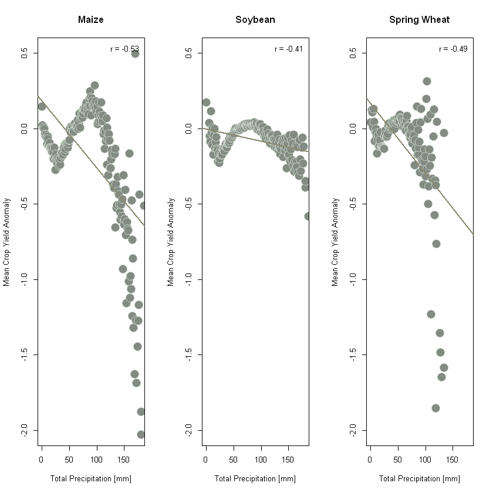

```r
# Set up a 1x3 multi-panel layout
par(mfrow = c(1, 3))

# Plot for maize
plot(mean_prec_maize$x, mean_prec_maize$y, pch = 21, cex = 2.5,bg = "honeydew4", col = "honeydew3",
     xlab = "Total Precipitation [mm]", ylab = "Mean Crop Yield Anomaly", main = "Maize", xlim = c(0, 180),ylim=c(-2,0.5))
correlation <- cor(mean_prec_maize$x, mean_prec_maize$y, use = "complete.obs")
legend("topright", paste("r =", round(correlation, 2)), bty = "n")
regression_model <- lm(y ~ x, data = mean_prec_maize)
abline(regression_model, col = "lemonchiffon4",lwd=2)

# Plot for soybean
plot(mean_prec_soybean$x, mean_prec_soybean$y, pch = 21, cex = 2.5,bg = "honeydew4", col = "honeydew3",
     xlab = "Total Precipitation [mm]", ylab = "Mean Crop Yield Anomaly", main = "Soybean", xlim = c(0, 180),ylim=c(-2,0.5))
correlation <- cor(mean_prec_soybean$x, mean_prec_soybean$y, use = "complete.obs")
legend("topright", paste("r =", round(correlation, 2)), bty = "n")
regression_model <- lm(y ~ x, data = mean_prec_soybean)
abline(regression_model, col = "lemonchiffon4",lwd=2)

# Plot for wheat
plot(mean_prec_wheat$x, mean_prec_wheat$y, pch = 21, cex = 2.5,bg = "honeydew4", col = "honeydew3",
     xlab = "Total Precipitation [mm]", ylab = "Mean Crop Yield Anomaly", main = "Spring Wheat", xlim = c(0, 180),ylim=c(-2,0.5))
correlation <- cor(mean_prec_wheat$x, mean_prec_wheat$y, use = "complete.obs")
legend("topright", paste("r =", round(correlation, 2)), bty = "n")
regression_model <- lm(y ~ x, data = mean_prec_wheat)
abline(regression_model, col = "lemonchiffon4",lwd=2)

# Reset the layout to a single panel
par(mfrow = c(1, 1))
```

# Multiple Linear Regression (Spatial Patterns)

### 1. MAIZE

```r
# Precipitation Coefficient
fun=function(x) { if (is.na(x[1])){ NA } else { m = lm(scale(x[1:35]) ~ scale(x[106:140]) + scale(x[141:175]));summary(m)$coefficients[2]}} #climate variables: Precipitation
maize.precipitation.coeff <- calc(datacube, fun)

# Air Temperature Mean
fun=function(x) { if (is.na(x[1])){ NA } else { m = lm(scale(x[1:35]) ~ scale(x[106:140]) + scale(x[141:175]));summary(m)$coefficients[3]}} #climate variables: Precipitation
maize.air.temperature.coeff <- calc(datacube, fun)

# rsquared
r2=function(x) { if (is.na(x[1])){ NA } else {m <- lm((x[1:35]) ~  (x[106:140]) + (x[141:175]));summary(m)$adj.r.squared}}
maize.rsquared <- calc(datacube, r2)

# student's t-test
ttest=function(x) { if (is.na(x[1])){ NA } else {m <- lm(scale(x[1:35]) ~ scale(x[106:140]) + scale(x[141:175])); pf(summary(m)$fstatistic["value"],summary(m)$fstatistic["numdf"],summary(m)$fstatistic["dendf"],lower.tail=F)}} #confidence intervall of 95%
maize.pvalue <- calc(datacube, ttest)

# alpha level 0.05
maize.sign <- maize.pvalue
maize.sign[maize.sign > 0.05] <- NA

# root mean error
rmse_=function(x) { if (is.na(x[1])){ NA } else {m <- lm(((x[1:35])) ~ + (x[106:140]) + (x[141:175])); sqrt(mean(m$residuals^2))}}
maize.rmse <- calc(datacube, rmse_)
```

Plot Maize

[figure not shown]

```r
par(mfrow = c(1, 6))
main_title <- "Maize "

# Plot each coefficient
plot(maize.precipitation.coeff, main= main_title, sub = "Precipitation Coefficient", axes= FALSE)
plot(maize.air.temperature.coeff, main= main_title, sub = "Air Temperature 2m Coefficient",axes= FALSE)
plot(maize.rsquared,     main= main_title, sub = "Adjusted R?",axes= FALSE)
plot(maize.pvalue,       main= main_title, sub = "p-value",axes= FALSE)
plot(maize.rmse,         main= main_title, sub = "RMSE",axes= FALSE)
plot(maize.sign,         main= main_title, sub = "alpha level 0.05",axes= FALSE)
```

### 2 SOYBEAN

```r
# Precipitation Coefficient
fun=function(x) { if (is.na(x[36])){ NA } else { m <-lm(scale(x[36:70]) ~ scale(x[106:140]) + scale(x[141:175]));summary(m)$coefficients[2]}} #climate variables: Precipitation
soybean.precipitation.coeff <- calc(datacube, fun)

# Air Temperature Mean
fun=function(x) { if (is.na(x[36])){ NA } else { m <- lm(scale(x[36:70]) ~ scale(x[106:140]) + scale(x[141:175]));summary(m)$coefficients[3]}} #climate variables: Precipitation
soybean.air.temperature.coeff <- calc(datacube, fun)

# rsquared
r2=function(x) { if (is.na(x[36])){ NA } else {m <- lm((x[36:70]) ~  (x[106:140]) + (x[141:175]));summary(m)$adj.r.squared}}
soybean.rsquared <- calc(datacube, r2)

# student's t-test
ttest=function(x) { if (is.na(x[36])){ NA } else {m <- lm(scale(x[36:70]) ~ scale(x[106:140]) + scale(x[141:175])); pf(summary(m)$fstatistic["value"],summary(m)$fstatistic["numdf"],summary(m)$fstatistic["dendf"],lower.tail=F)}} #confidence intervall of 95%
soybean.pvalue <- calc(datacube, ttest)

# alpha level 0.05
soybean.sign <- soybean.pvalue
soybean.sign[soybean.sign > 0.05] <- NA

# root mean error
rmse_=function(x) { if (is.na(x[36])){ NA } else {m <- lm(((x[36:70])) ~ + (x[106:140]) + (x[141:175])); sqrt(mean(m$residuals^2))}}
soybean.rmse <- calc(datacube, rmse_)
```

Plot Soybean

[figure not shown]

```r
par(mfrow = c(1, 6))
main_title <- "Soybean "

# Plot each coefficient
plot(soybean.precipitation.coeff, main= main_title, sub = "Precipitation Coefficient", axes= FALSE)
plot(soybean.air.temperature.coeff, main= main_title, sub = "Air Temperature 2m Coefficient",axes= FALSE)
plot(soybean.rsquared,     main= main_title, sub = "Adjusted R?",axes= FALSE)
plot(soybean.pvalue,       main= main_title, sub = "p-value",axes= FALSE)
plot(soybean.rmse,         main= main_title, sub = "RMSE",axes= FALSE)
plot(soybean.sign,         main= main_title, sub = "alpha level 0.05",axes= FALSE)
```

### 3 SPRING WHEAT

```r
# Precipitation Coefficient
fun=function(x) { if (is.na(x[71])){ NA } else {m <- lm(scale(x[71:105]) ~ scale(x[106:140]) + scale(x[141:175]));summary(m)$coefficients[2]}} #climate variables: Precipitation
wheat.precipitation.coeff <- calc(datacube, fun)

# Air Temperature Mean
fun=function(x) { if (is.na(x[71])){ NA } else {m <- lm(scale(x[71:105]) ~ scale(x[106:140]) + scale(x[141:175]));summary(m)$coefficients[3]}} #climate variables: Precipitation
wheat.air.temperature.coeff <- calc(datacube, fun)

# rsquared
r2=function(x) { if (is.na(x[71])){ NA } else {m <- lm((x[71:105]) ~  (x[106:140]) + (x[141:175]));summary(m)$adj.r.squared}}
wheat.rsquared <- calc(datacube, r2)

# student's t-test
ttest=function(x) { if (is.na(x[71])){ NA } else {m <- lm(scale(x[71:105]) ~ scale(x[106:140]) + scale(x[141:175])); pf(summary(m)$fstatistic["value"],summary(m)$fstatistic["numdf"],summary(m)$fstatistic["dendf"],lower.tail=F)}} #confidence intervall of 95%
wheat.pvalue <- calc(datacube, ttest)

# alpha level 0.05
wheat.sign <- wheat.pvalue
wheat.sign[wheat.sign > 0.05] <- NA

# root mean error
rmse_=function(x) { if (is.na(x[71])){ NA } else {m <- lm(((x[71:105])) ~ + (x[106:140]) + (x[141:175])); sqrt(mean(m$residuals^2))}}
wheat.rmse <- calc(datacube, rmse_)
```

Plot Spring Wheat

[figure not shown]

```r
par(mfrow = c(1, 6))
main_title <- "Spring wheat "

# Plot each coefficient
plot(wheat.precipitation.coeff, main= main_title, sub = "Precipitation Coefficient", axes= FALSE)
plot(wheat.air.temperature.coeff, main= main_title, sub = "Air Temperature 2m Coefficient",axes= FALSE)
plot(wheat.rsquared,     main= main_title, sub = "Adjusted R?",axes= FALSE)
plot(wheat.pvalue,       main= main_title, sub = "p-value",axes= FALSE)
plot(wheat.rmse,         main= main_title, sub = "RMSE",axes= FALSE)
plot(wheat.sign,         main= main_title, sub = "alpha level 0.05",axes= FALSE)
```

Plots were edited in QGIS